# **VRCC – exploratory analysis**

Pawel Motyka, Felix Klotzsche, Aleksander Molak *pmotyka@psych.pan.pl* *klotzsche@cbs.mpg.de* *aleksander.molak@gmail.com

Jan 2024

**List of sections**:

- S1 – Load required packages and data
- S2 - Comparison of localization error between cardiac phases
- S3 - RR interval length and distance estimates
- S4 - Animal assessment - threat, disgust, and speed ratings
- S5 - Distance error as a function of subjective threat
- S6 - Distance error as a function of anxiety levels, disgust, and speed ratings
- S7 - Cybersickness (SSQ) and presence in VR (SUS)
- S8 - Distance errors as a function of real distance
- S9 - Distribution of stimulus onsets across the cardiac cycle

**1. Load required packages and data**

```r
# Utils
library(dplyr)
library(here)
library(tidyr)
source(here("./Code/Analyses/VRTask/Utils/stats_utils.r"))

# Plotting and tables
library(ggplot2)
library(sjPlot)
library(gghalves)
library(colorspace)

# Statistical tools
library(lme4)
library(lmtest)
library(lmerTest)
library(car)
library(effsize)
library(psych)
library(Rmisc)
library(afex)
library(circular)

# Set up the fulldata directory
VRCC_dir  <- here::here()

# read behavioral & ecg data
data <- read.csv(file = paste0(VRCC_dir,"/Data/VRTask/VRCC_data_consolidated-2023-08-10.csv"))

# read intial ratings data
d_sub_start <- read.csv(file = paste0(VRCC_dir,"/Data/VRTask/Ratings/VRCC_data_initial_subjective_ratings.csv"))

# read mid-experimental ratings data
d_sub_mid <- read.csv(file = paste0(VRCC_dir,"/Data/VRTask/Ratings/VRCC_data_mid-experimental_subjective_ratings.csv"))
d_sub_mid$threat[d_sub_mid$threat == 0] <- NA # add NAs

# read questionnaires data
d_qstn <- read.csv(file = paste0(VRCC_dir,"/Data/VRTask/Ratings/VRCC_data_questionnaires.csv"))

# conversion of distance from m to cm
data <- data %>%
mutate(EstimatedDistance = EstimatedDistance * 100, RealDistance = RealDistance * 100, DistanceError = DistanceError * 100 , DistanceErrorAbs = DistanceErrorAbs * 100, LocalizationError = LocalizationError * 100)
```

**2. Comparison of localization error between cardiac phases**

```r
# Localization error

d <- data[data$c_phase == "systole" | data$c_phase == "diastole",]

d <- dplyr::select(d, ID, LocalizationError, c_phase)
d <- d %>% dplyr::group_by(ID, c_phase)  %>% dplyr::summarize(LocalizationError = mean(LocalizationError))
```

```
## argument.
```

```r
d <- pivot_wider(d, names_from = c(c_phase), values_from = LocalizationError)

# perform t-test
shapiro.test(d$diastole)
```

```
##
##  Shapiro-Wilk normality test
##
## data:  d$diastole
## W = 0.7814, p-value = 2.27e-06
```

```r
shapiro.test(d$systole)
```

```
##
##  Shapiro-Wilk normality test
##
## data:  d$systole
## W = 0.81049, p-value = 9.176e-06
```

```r
describe(d$diastole)
```

```
##    vars  n mean    sd median trimmed  mad   min   max range skew kurtosis   se
## X1    1 41 41.8 15.59  36.73   38.93 6.46 25.84 89.75 63.91 1.71     2.35 2.44
```

```r
describe(d$systole)
```

```
##    vars  n  mean    sd median trimmed  mad   min   max range skew kurtosis   se
## X1    1 41 42.04 15.66  37.57   39.24 7.99 24.71 96.09 71.38 1.71     2.71 2.45
```

```r
wilcox.test(d$systole, d$diastole, paired = T)
```

```
##
##  Wilcoxon signed rank exact test
##
## data:  d$systole and d$diastole
## V = 464, p-value = 0.6721
## alternative hypothesis: true location shift is not equal to 0
```

```r
#boxplot(d$systole, d$diastole, names = c("Systole", "Diastole"), ylim = c(0,1))
```

**3. RR interval length and distance estimates**

```r
### 3.1 RR interval - distance & localization errors

d <- dplyr::select(data, ID, DistanceError, LocalizationError, RRLength)
d <- d %>% dplyr::group_by(ID) %>% dplyr::summarize(LocalizationError = mean(LocalizationError), DistanceError = mean(DistanceError), RRLength = mean(RRLength))

shapiro.test(d$LocalizationError)
```

```
##
##  Shapiro-Wilk normality test
##
## data:  d$LocalizationError
## W = 0.79304, p-value = 3.916e-06
```

```r
shapiro.test(d$DistanceError)
```

```
##
##  Shapiro-Wilk normality test
##
## data:  d$DistanceError
## W = 0.95708, p-value = 0.1243
```

```r
shapiro.test(d$RRLength)
```

```
##
##  Shapiro-Wilk normality test
##
## data:  d$RRLength
## W = 0.97466, p-value = 0.4825
```

```r
cor.test(d$RRLength, d$DistanceError, method = "pearson")
```

```
##
##  Pearson's product-moment correlation
##
## data:  d$RRLength and d$DistanceError
## t = -0.40016, df = 39, p-value = 0.6912
## alternative hypothesis: true correlation is not equal to 0
## 95 percent confidence interval:
##  -0.3644266  0.2485956
## sample estimates:
##         cor
## -0.06394547
```

```r
cor.test(d$RRLength, d$LocalizationError, method = "spearman")
```

```
##
##  Spearman's rank correlation rho
##
## data:  d$RRLength and d$LocalizationError
## S = 10612, p-value = 0.6374
## alternative hypothesis: true rho is not equal to 0
## sample estimates:
##        rho
## 0.07560976
```

**4. Animal assessment - threat, disgust, and speed ratings**

```r
###. 4.1. Separate groups (threat, disgust, speed ratings)

di <- d_sub_start
di <- di %>% dplyr::group_by(ID, fear_object) %>% dplyr::summarize(threat = mean(threat), disgust = mean(disgust), speed = mean(how_fast))
```

```
## argument.
```

```r
di <- pivot_wider(di, names_from = c(fear_object), values_from = c(threat, disgust, speed))

# threat
shapiro.test(di$threat_False)
```

```
##
##  Shapiro-Wilk normality test
##
## data:  di$threat_False
## W = 0.79385, p-value = 4.07e-06
```

```r
shapiro.test(di$threat_True)
```

```
##
##  Shapiro-Wilk normality test
##
## data:  di$threat_True
## W = 0.93124, p-value = 0.01588
```

```r
wilcox.test(di$threat_True, di$threat_False, paired = T,  alternative = "two.sided", exact = F)
```

```
##
##  Wilcoxon signed rank test with continuity correction
##
## data:  di$threat_True and di$threat_False
## V = 780, p-value = 5.367e-08
## alternative hypothesis: true location shift is not equal to 0
```

```r
describe(di$threat_False)
```

```
##    vars  n mean   sd median trimmed  mad min  max range skew kurtosis   se
## X1    1 41 1.31 0.38   1.25    1.25 0.37   1 2.25  1.25 1.03    -0.11 0.06
```

```r
describe(di$threat_True)
```

```
##    vars  n mean   sd median trimmed  mad min max range  skew kurtosis   se
## X1    1 41 4.57 1.63   4.75    4.72 1.85   1   7     6 -0.65    -0.62 0.25
```

```r
# disgust
shapiro.test(di$disgust_False)
```

```
##
##  Shapiro-Wilk normality test
##
## data:  di$disgust_False
## W = 0.78167, p-value = 2.297e-06
```

```r
shapiro.test(di$disgust_True)
```

```
##
##  Shapiro-Wilk normality test
##
## data:  di$disgust_True
## W = 0.92168, p-value = 0.007724
```

```r
wilcox.test(di$disgust_True, di$disgust_False, paired = T,  alternative = "two.sided", exact = F)
```

```
##
##  Wilcoxon signed rank test with continuity correction
##
## data:  di$disgust_True and di$disgust_False
## V = 618, p-value = 6.964e-07
## alternative hypothesis: true location shift is not equal to 0
```

```r
describe(di$disgust_False)
```

```
##    vars  n mean   sd median trimmed  mad min max range skew kurtosis   se
## X1    1 41 1.34 0.43   1.25    1.27 0.37   1 2.5   1.5 1.27     0.71 0.07
```

```r
describe(di$disgust_True)
```

```
##    vars  n mean   sd median trimmed  mad min  max range skew kurtosis   se
## X1    1 41 2.74 1.48   2.75     2.6 1.85   1 6.75  5.75 0.64    -0.23 0.23
```

```r
# speed
shapiro.test(di$speed_False)
```

```
##
##  Shapiro-Wilk normality test
##
## data:  di$speed_False
## W = 0.96662, p-value = 0.2662
```

```r
shapiro.test(di$speed_True)
```

```
##
##  Shapiro-Wilk normality test
##
## data:  di$speed_True
## W = 0.97112, p-value = 0.3749
```

```r
t.test(di$speed_True, di$speed_False, paired = T,  alternative = "two.sided")
```

```
##
##  Paired t-test
##
## data:  di$speed_True and di$speed_False
## t = 10.72, df = 40, p-value = 2.504e-13
## alternative hypothesis: true difference in means is not equal to 0
## 95 percent confidence interval:
##  1.246888 1.826282
## sample estimates:
## mean of the differences
##                1.536585
```

```r
describe(di$speed_False)
```

```
##    vars  n mean   sd median trimmed  mad min max range  skew kurtosis   se
## X1    1 41 3.52 0.87    3.5    3.55 1.11 1.5   5   3.5 -0.13    -0.72 0.14
```

```r
describe(di$speed_True)
```

```
##    vars  n mean   sd median trimmed  mad min max range  skew kurtosis   se
## X1    1 41 5.06 0.97   5.25    5.08 1.11   3   7     4 -0.25    -0.63 0.15
```

```r
###. 4.2. Invididual animals (threat, disgust, speed)

di <- d_sub_start
di <- di %>% dplyr::group_by(ID, Stimulus) %>% dplyr::summarize(threat = mean(threat), disgust = mean(disgust), speed = mean(how_fast))
```

```
## argument.
```

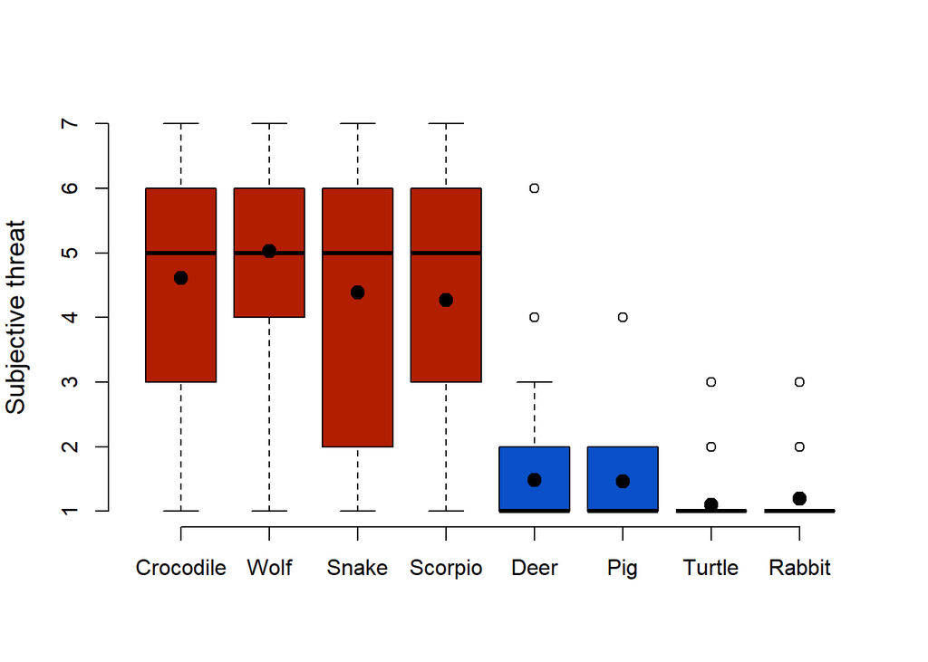

```r
dis <- pivot_wider(di, names_from = c(Stimulus), values_from = c(threat, disgust, speed))

cR <- rgb(178/255, 31/255, 0/255)
cB <- rgb(10/255, 80/255, 200/255)

# threat
boxplot(dis$threat_Crocodile, dis$threat_FinalWolf, dis$threat_FinalSnake, dis$threat_Scorpio, dis$threat_Deer, dis$threat_Pig,  dis$threat_Turtle, dis$threat_Rabbit, col = c(cR, cR, cR, cR, cB, cB, cB,cB), names = c("Crocodile", "Wolf", "Snake", "Scorpio", "Deer", "Pig", "Turtle", "Rabbit"), frame = FALSE, notch = F, ylab = "Subjective threat", cex.lab = 1.2, cex.axis = 1, ylim = c(1,7))
abline(h=0, col="gray20", lwd = 1.3, lty = 2)

points(c(mean(dis$threat_Crocodile, na.rm = T), mean(dis$threat_FinalWolf, na.rm = T), mean(dis$threat_FinalSnake, na.rm = T), mean(dis$threat_Scorpio, na.rm = T), mean(dis$threat_Deer, na.rm = T),mean(dis$threat_Pig, na.rm = T),mean(dis$threat_Turtle, na.rm = T),mean(dis$threat_Rabbit, na.rm = T)), pch = 19, cex = 1.4)
```

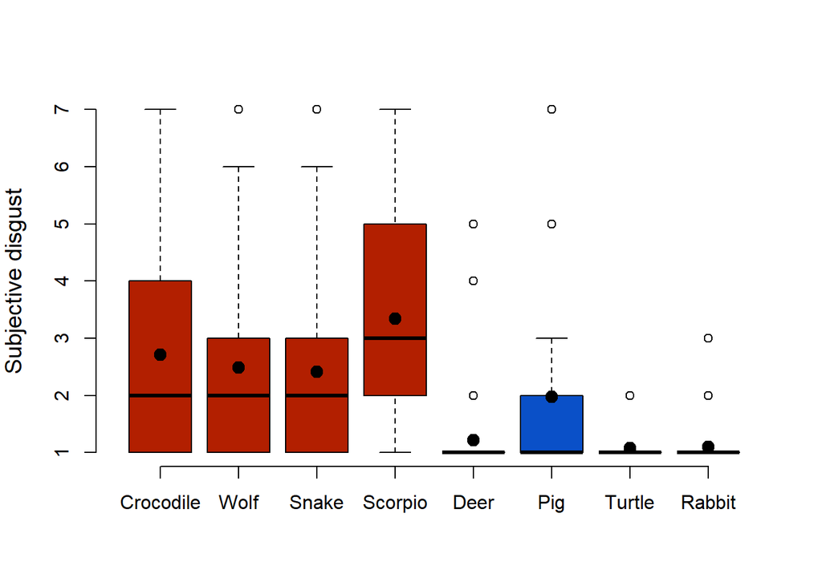

```r
# export 3.5 x 7 cm

# disgust
boxplot(dis$disgust_Crocodile, dis$disgust_FinalWolf, dis$disgust_FinalSnake, dis$disgust_Scorpio, dis$disgust_Deer, dis$disgust_Pig,  dis$disgust_Turtle, dis$disgust_Rabbit, col = c(cR, cR, cR, cR, cB, cB, cB,cB), names = c("Crocodile", "Wolf", "Snake", "Scorpio", "Deer", "Pig", "Turtle", "Rabbit"), frame = FALSE, notch = F, ylab = "Subjective disgust", cex.lab = 1.2, cex.axis = 1, ylim = c(1,7))
abline(h=0, col="gray20", lwd = 1.3, lty = 2)

points(c(mean(dis$disgust_Crocodile, na.rm = T), mean(dis$disgust_FinalWolf, na.rm = T), mean(dis$disgust_FinalSnake, na.rm = T), mean(dis$disgust_Scorpio, na.rm = T), mean(dis$disgust_Deer, na.rm = T),mean(dis$disgust_Pig, na.rm = T),mean(dis$disgust_Turtle, na.rm = T),mean(dis$disgust_Rabbit, na.rm = T)), pch = 19, cex = 1.4)
```

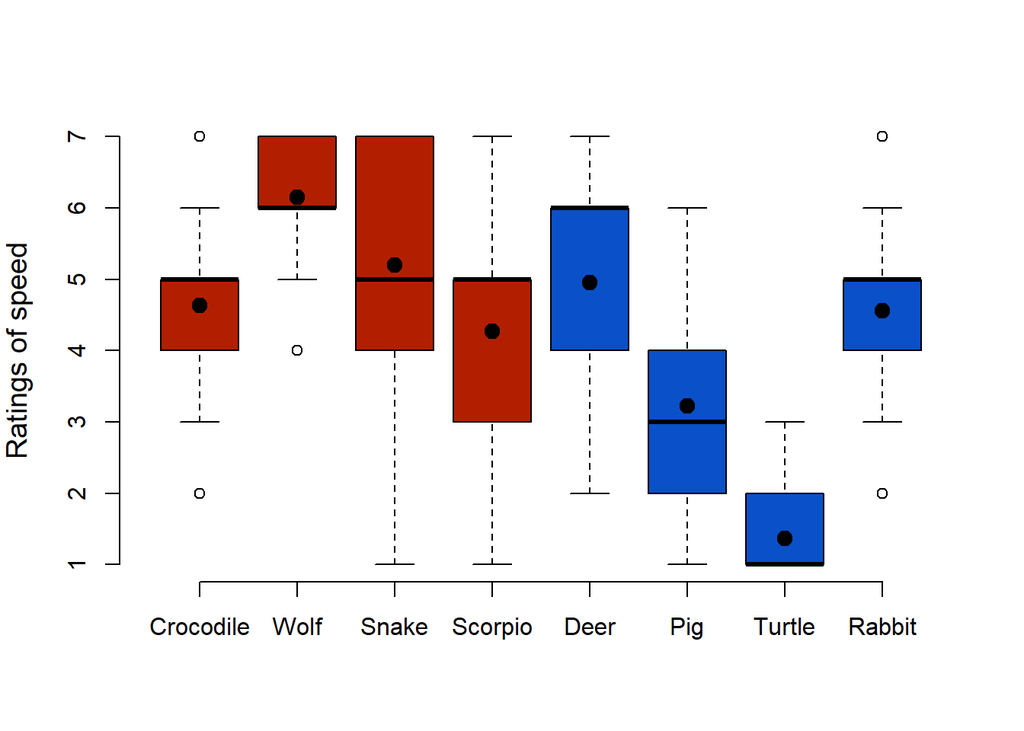

```r
# export 3.5 x 7 cm

# speed
boxplot(dis$speed_Crocodile, dis$speed_FinalWolf, dis$speed_FinalSnake, dis$speed_Scorpio, dis$speed_Deer, dis$speed_Pig,  dis$speed_Turtle, dis$speed_Rabbit, col = c(cR, cR, cR, cR, cB, cB, cB,cB), names = c("Crocodile", "Wolf", "Snake", "Scorpio", "Deer", "Pig", "Turtle", "Rabbit"), frame = FALSE, notch = F, ylab = "Ratings of speed", cex.lab = 1.2, cex.axis = 1, ylim = c(1,7))
abline(h=0, col="gray20", lwd = 1.3, lty = 2)

points(c(mean(dis$speed_Crocodile, na.rm = T), mean(dis$speed_FinalWolf, na.rm = T), mean(dis$speed_FinalSnake, na.rm = T), mean(dis$speed_Scorpio, na.rm = T), mean(dis$speed_Deer, na.rm = T),mean(dis$speed_Pig, na.rm = T),mean(dis$speed_Turtle, na.rm = T),mean(dis$speed_Rabbit, na.rm = T)), pch = 19, cex = 1.4)
```

```r
# export 3.5 x 7 cm


### 4.3.  Block-by-block/mid-experimental threat ratings

# threatening vs non-threatening difference
mid_averaged <- d_sub_mid %>%
  dplyr::group_by(ID, fear_object) %>%
  dplyr::summarize(threat = mean(threat, na.rm = T))
```

```
## argument.
```

```r
mid_averaged <- pivot_wider(mid_averaged, names_from = fear_object, values_from = threat)

shapiro.test(mid_averaged$False)
```

```
##
##  Shapiro-Wilk normality test
##
## data:  mid_averaged$False
## W = 0.68857, p-value = 4.884e-08
```

```r
shapiro.test(mid_averaged$True)
```

```
##
##  Shapiro-Wilk normality test
##
## data:  mid_averaged$True
## W = 0.8912, p-value = 0.0009214
```

```r
wilcox.test(mid_averaged$True, mid_averaged$False, paired = T,  alternative = "two.sided", exact = F)
```

```
##
##  Wilcoxon signed rank test with continuity correction
##
## data:  mid_averaged$True and mid_averaged$False
## V = 780, p-value = 5.459e-08
## alternative hypothesis: true location shift is not equal to 0
```

```r
describe(mid_averaged$False)
```

```
##    vars  n mean   sd median trimmed  mad min  max range skew kurtosis   se
## X1    1 41 1.28 0.42   1.09    1.19 0.13   1 3.17  2.17 2.46      7.5 0.07
```

```r
describe(mid_averaged$True)
```

```
##    vars  n mean   sd median trimmed  mad min max range  skew kurtosis   se
## X1    1 41 4.26 1.81      5    4.35 1.48   1   7     6 -0.53    -1.19 0.28
```

```r
# block-by-block changes
qb <- d_sub_mid %>%
  dplyr::group_by(ID, fear_object, Round) %>%
  dplyr::summarize(threat = mean(threat, na.rm = T))
```

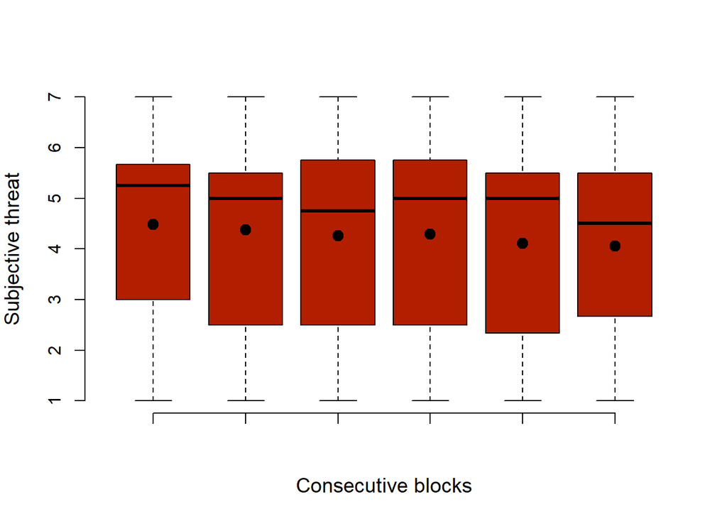

```r
qb <- qb[qb$fear_object == "True",]

cR <- rgb(178/255, 31/255, 0/255)

boxplot(qb$threat[qb$Round == 1], qb$threat[qb$Round == 2], qb$threat[qb$Round == 3], qb$threat[qb$Round == 4],qb$threat[qb$Round == 5],qb$threat[qb$Round == 6], ylab = "Subjective threat", xlab = "Consecutive blocks", col = cR,
frame = FALSE, notch = F, cex.lab = 1.2, cex.axis = 1)

points(c(mean(qb$threat[qb$Round == 1], na.rm = T), mean(qb$threat[qb$Round == 2], na.rm = T), mean(qb$threat[qb$Round == 3], na.rm = T), mean(qb$threat[qb$Round == 4], na.rm = T),mean(qb$threat[qb$Round == 5], na.rm = T),mean(qb$threat[qb$Round == 6], na.rm = T)), pch = 19, cex = 1.4)
```

```r
# run analysis
fit_all <- aov_ez(data = qb, dv = "threat", id = "ID", within="Round", return = afex_options("return_aov"), anova_table = list(), fun_aggregate = mean)
fit_all
```

```
## Anova Table (Type 3 tests)
##
## Response: threat
##   Effect           df  MSE       F  ges p.value
## 1  Round 2.70, 108.08 0.44 4.43 ** .006    .007
## ---
## Signif. codes:  0 '***' 0.001 '**' 0.01 '*' 0.05 '+' 0.1 ' ' 1
##
## Sphericity correction method: GG
```

```r
summary(fit_all) # see epsilon values
```

```
##
## Univariate Type III Repeated-Measures ANOVA Assuming Sphericity
##
##             Sum Sq num Df Error SS den Df  F value    Pr(>F)
## (Intercept) 4469.6      1   786.22     40 227.3989 < 2.2e-16 ***
## Round          5.3      5    47.97    200   4.4311  0.000753 ***
## ---
## Signif. codes:  0 '***' 0.001 '**' 0.01 '*' 0.05 '.' 0.1 ' ' 1
##
##
## Mauchly Tests for Sphericity
##
##       Test statistic    p-value
## Round        0.18496 2.1704e-08
##
##
## Greenhouse-Geisser and Huynh-Feldt Corrections
##  for Departure from Sphericity
##
##        GG eps Pr(>F[GG])
## Round 0.54042   0.007334 **
## ---
## Signif. codes:  0 '***' 0.001 '**' 0.01 '*' 0.05 '.' 0.1 ' ' 1
##
##          HF eps  Pr(>F[HF])
## Round 0.5833379 0.005909059
```

```r
# post-hoc comparisons (Bonferroni correction)
ref <- emmeans::emmeans(fit_all, specs = "Round")
ref
```

```
##  Round emmean    SE df lower.CL upper.CL
##  X1      4.49 0.277 40     3.93     5.05
##  X2      4.37 0.271 40     3.83     4.92
##  X3      4.26 0.306 40     3.64     4.88
##  X4      4.29 0.301 40     3.68     4.90
##  X5      4.11 0.301 40     3.50     4.72
##  X6      4.05 0.289 40     3.47     4.64
##
## Confidence level used: 0.95
```

```r
emmeans::contrast(ref,method="pairwise",adjust="bonferroni")
```

```
##  contrast estimate     SE df t.ratio p.value
##  X1 - X2    0.1138 0.1032 40   1.103  1.0000
##  X1 - X3    0.2276 0.1353 40   1.683  1.0000
##  X1 - X4    0.2012 0.1341 40   1.500  1.0000
##  X1 - X5    0.3760 0.1541 40   2.440  0.2882
##  X1 - X6    0.4329 0.1474 40   2.937  0.0821
##  X2 - X3    0.1138 0.0932 40   1.221  1.0000
##  X2 - X4    0.0874 0.1000 40   0.874  1.0000
##  X2 - X5    0.2622 0.1125 40   2.331  0.3736
##  X2 - X6    0.3191 0.1202 40   2.655  0.1700
##  X3 - X4   -0.0264 0.0740 40  -0.357  1.0000
##  X3 - X5    0.1484 0.0737 40   2.015  0.7606
##  X3 - X6    0.2053 0.0956 40   2.148  0.5669
##  X4 - X5    0.1748 0.0762 40   2.294  0.4072
##  X4 - X6    0.2317 0.0739 40   3.136  0.0481
##  X5 - X6    0.0569 0.0773 40   0.736  1.0000
##
## P value adjustment: bonferroni method for 15 tests
```

```r
# Compare threat vs non-threat ratings before final block
d_sub_mid %>%
  filter(Round == 6) %>%
  group_by(ID, fear_object) %>%
  dplyr::summarise(m_rat = mean(threat, na.rm=TRUE)) -> dat_r6
```

```
## argument.
```

```r
t.test(m_rat~fear_object, data = dat_r6, paired = TRUE)
```

```
##
##  Paired t-test
##
## data:  m_rat by fear_object
## t = -10.264, df = 40, p-value = 9.07e-13
## alternative hypothesis: true difference in means is not equal to 0
## 95 percent confidence interval:
##  -3.284221 -2.203584
## sample estimates:
## mean of the differences
##               -2.743902
```

```r
shapiro.test(dat_r6 %>%
               ungroup() %>%
               filter(fear_object == "True") %>%
               pull(m_rat))
```

```
##
##  Shapiro-Wilk normality test
##
## data:  dat_r6 %>% ungroup() %>% filter(fear_object == "True") %>% pull(m_rat)
## W = 0.92391, p-value = 0.009114
```

```r
shapiro.test(dat_r6 %>%
               ungroup() %>%
               filter(fear_object == "False") %>%
               pull(m_rat))
```

```
##
##  Shapiro-Wilk normality test
##
## data:  dat_r6 %>% ungroup() %>% filter(fear_object == "False") %>% pull(m_rat)
## W = 0.65439, p-value = 1.424e-08
```

```r
wilcox.test(m_rat~fear_object, data = dat_r6, paired = TRUE)
```

```
##
##  Wilcoxon signed rank test with continuity correction
##
## data:  m_rat by fear_object
## V = 0, p-value = 2.538e-07
## alternative hypothesis: true location shift is not equal to 0
```

```r
# same result as t test



dat_r6 %>%
  group_by(fear_object) %>%
  dplyr::summarise(grand_m = mean(m_rat),
                   sd = sd(m_rat)) -> dat_r6_desc

dat_r6_desc
```

```
## # A tibble: 2 x 3
##   fear_object grand_m    sd
##   <chr>         <dbl> <dbl>
## 1 False          1.31 0.533
## 2 True           4.05 1.85
```

```r
### 4.4. Stimulus recognition task
dm <- d_sub_mid
# % of unrecognized objects
length(dm$recognize[dm$recognize == 0]) / nrow(dm)
```

```
## [1] 0.0472561
```

```r
# from 18 subjects
length(unique(dm$ID[dm$recognize == 0]))
```

```
## [1] 18
```

**5. Distance error as a function of subjective threat**

```r
# merge initial and mid-experimental threat ratings to get overall average
dm <- d_sub_mid
dm <- dm %>%
  group_by(ID, Stimulus) %>%
  dplyr::summarize(threat = mean(threat, na.rm = T))
```

```
## argument.
```

```r
di <- d_sub_start
di <- di %>% dplyr::rename("threat_start" = "threat")

d <- inner_join(dm, di)
# check correlations between initial and mid-experimental ratings
for (s in unique(d$Stimulus[d$fear_object == T])) {

ds <- d[d$Stimulus == s,]

cor <- cor.test(ds$threat, ds$threat_start, method = "spearman")
rho <- round(cor$estimate, digits = 3)
p_val <- round(cor$p.value, digits = 3)

scatter.smooth(ds$threat, ds$threat_start, main = paste0(s, "\n(rho = ", rho, ", p = ",p_val,")"), pch = 20, cex = 2, col = scales::alpha("firebrick",0.5), lwd = 2, xlim = c(0,7), ylim = c(0,7))
}

# merge data
dm <- d_sub_mid[,c(1,3,4,5,7)]
di <- d_sub_start
di <- di[,c(1,3,7,8)]
di$Round <- 0 # save initial rating as 'block 0'
dss <- rbind(di,dm)
dss <- dss[dss$fear_object == "True",]

# save average threat ratings
d <- dss %>%
  dplyr::group_by(ID, Stimulus) %>%
  dplyr::summarize(threat = mean(threat, na.rm = T))
```

[output not shown]

```
## argument.
```

```r
# merge threat ratings with behavioral data
data_t <- data[data$FearObject == "True",]
dt <- merge(data_t,d, by = c("ID", "Stimulus"))

# prepare data for analysis & plotting
dt <- dt %>%
  dplyr::group_by(ID, Stimulus) %>%
  dplyr::summarize(distance_error  = mean(DistanceError), threat = mean(threat))
```

```
## argument.
```

```
##
##  Shapiro-Wilk normality test
##
## data:  ds$threat
## W = 0.90348, p-value = 0.002105
##
##
##  Shapiro-Wilk normality test
##
## data:  ds$distance_error
## W = 0.98104, p-value = 0.715
##
## [1] "Crocodile"
##
##  Spearman's rank correlation rho
##
## data:  ds$threat and ds$distance_error
## S = 11243, p-value = 0.8979
## alternative hypothesis: true rho is not equal to 0
## sample estimates:
##        rho
## 0.02067434
```

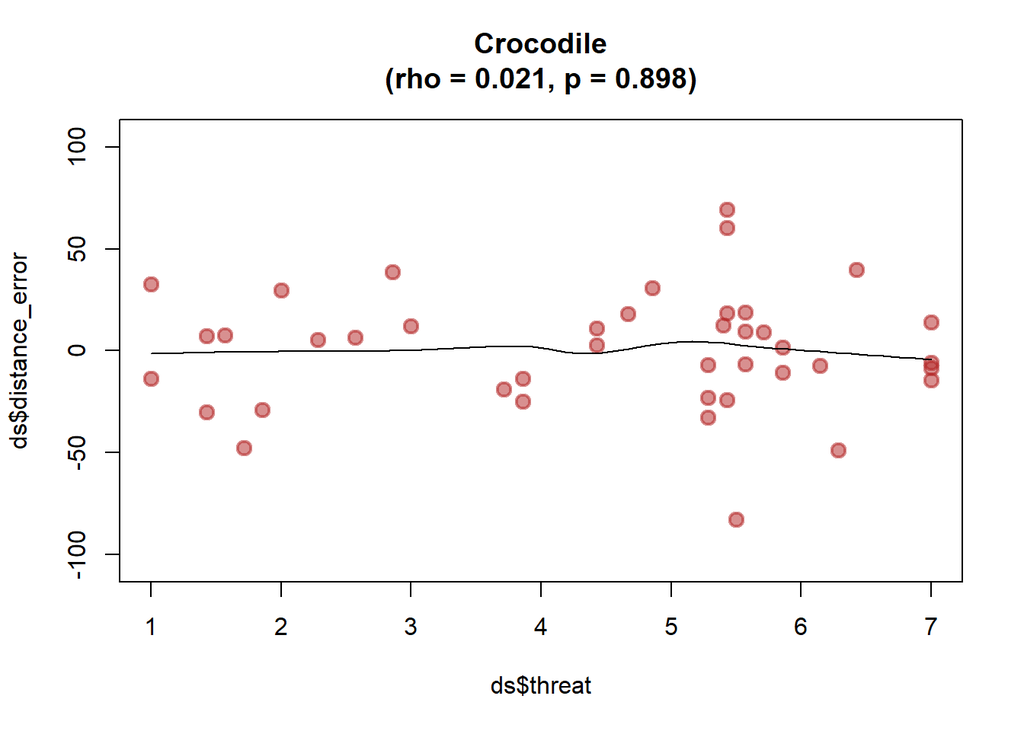

```
##
##  Shapiro-Wilk normality test
##
## data:  ds$threat
## W = 0.92152, p-value = 0.007633
##
##
##  Shapiro-Wilk normality test
##
## data:  ds$distance_error
## W = 0.97111, p-value = 0.3744
##
## [1] "FinalSnake"
##
##  Spearman's rank correlation rho
##
## data:  ds$threat and ds$distance_error
## S = 12407, p-value = 0.6158
## alternative hypothesis: true rho is not equal to 0
## sample estimates:
##         rho
## -0.08073942
```

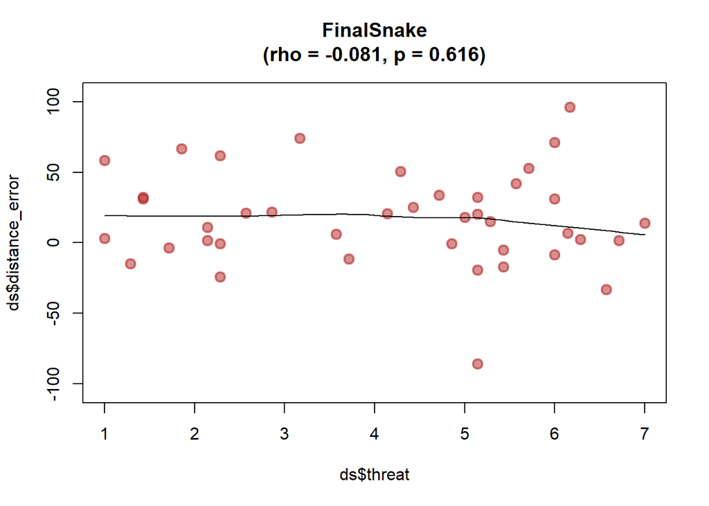

```
##
##  Shapiro-Wilk normality test
##
## data:  ds$threat
## W = 0.88589, p-value = 0.0006522
##
##
##  Shapiro-Wilk normality test
##
## data:  ds$distance_error
## W = 0.92959, p-value = 0.014
##
## [1] "FinalWolf"
##
##  Spearman's rank correlation rho
##
## data:  ds$threat and ds$distance_error
## S = 14151, p-value = 0.1432
## alternative hypothesis: true rho is not equal to 0
## sample estimates:
##        rho
## -0.2326881
```

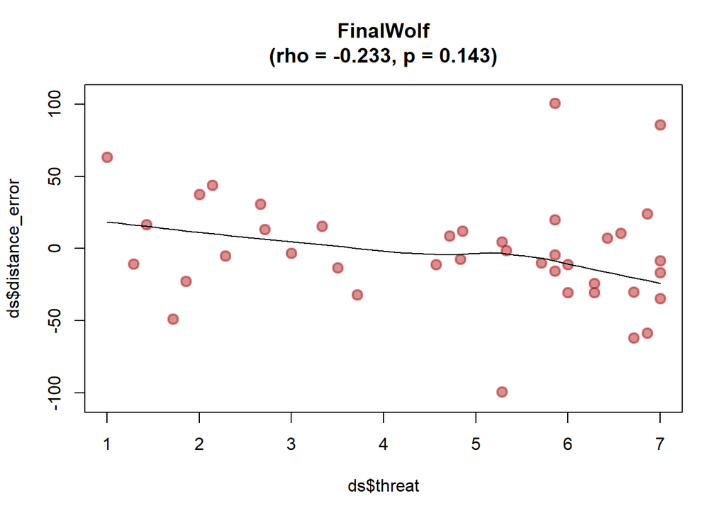

```
##
##  Shapiro-Wilk normality test
##
## data:  ds$threat
## W = 0.94504, p-value = 0.04694
##
##
##  Shapiro-Wilk normality test
##
## data:  ds$distance_error
## W = 0.9713, p-value = 0.3798
##
## [1] "Scorpio"
##
##  Spearman's rank correlation rho
##
## data:  ds$threat and ds$distance_error
## S = 11693, p-value = 0.9083
## alternative hypothesis: true rho is not equal to 0
## sample estimates:
##         rho
## -0.01856938
```

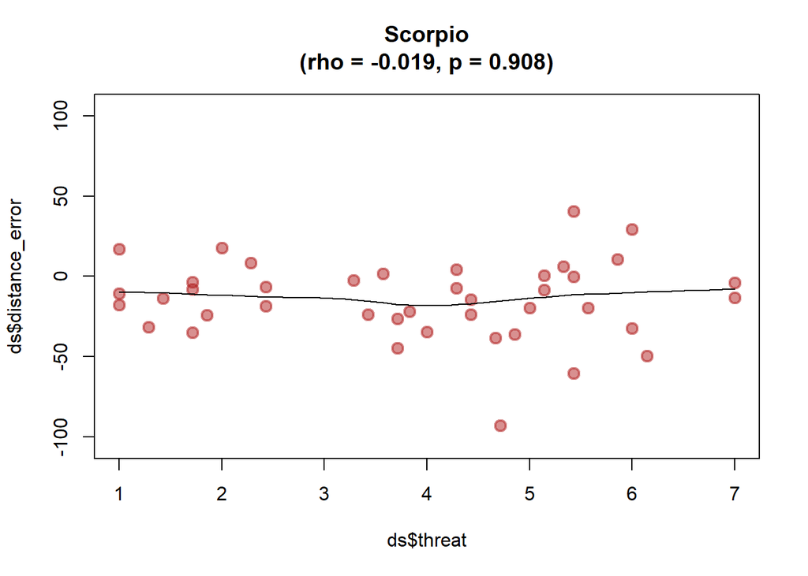

```r
# plot raw figures with correlation results
for (s in unique(dt$Stimulus)) {

  ds <- dt[dt$Stimulus == s,]

print(shapiro.test(ds$threat))
print(shapiro.test(ds$distance_error))

print(s)
cor <- cor.test(ds$threat, ds$distance_error, method = "spearman")
print(cor)

rho <- round(cor$estimate, digits = 3)
p_val <- round(cor$p.value, digits = 3)

scatter.smooth(ds$threat, ds$distance_error, main = paste0(s, "\n(rho = ", rho, ", p = ",p_val,")"), pch = 20, cex = 2, col = scales::alpha("firebrick",0.5), lwd = 2, xlim = c(1,7), ylim = c(-105,105))
}
```

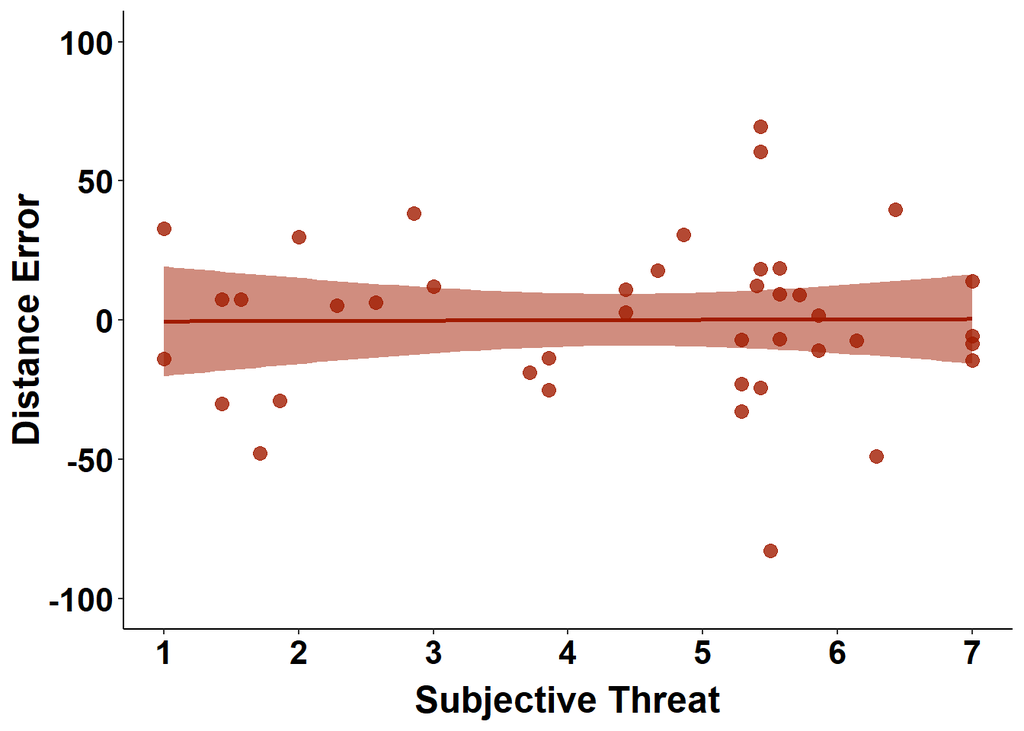

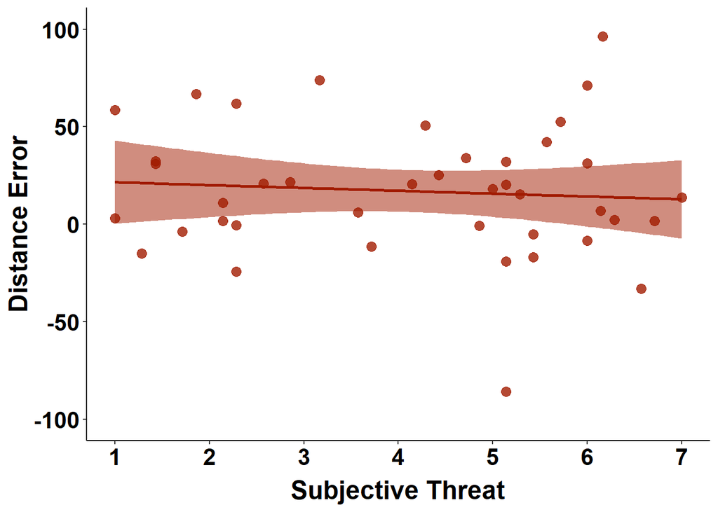

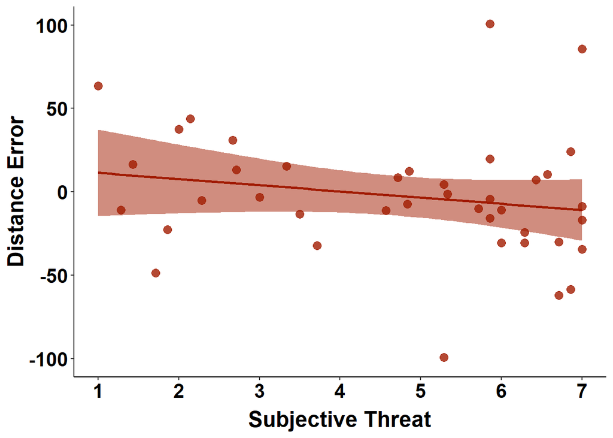

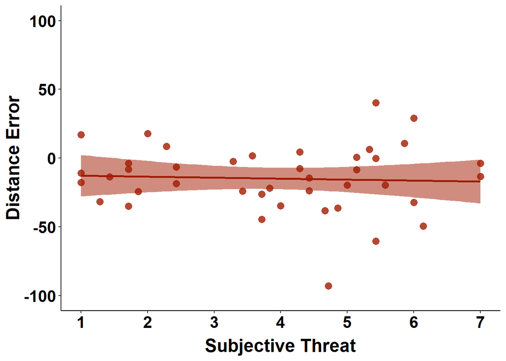

```r
# plot finalized figures
bold.text <- element_text(face = "bold", color = "black")
cR <- darken(rgb(178/255, 31/255, 0/255), 0.1)

par(mfrow=c(1,4))

for (s in unique(dt$Stimulus)) {

  d <- dt[dt$Stimulus == s,]

Fig1 <- ggplot(data = d, aes(x = threat, y = distance_error)) + geom_smooth(col = cR, fill = cR,method = "lm", level=0.95, alpha = 0.5) +  geom_point(col = cR, alpha = 0.8, size = 3, shape = 19) +   labs(x = "Subjective Threat", y = "Distance Error") + scale_fill_manual() + theme_classic() +  theme(axis.text=element_text(size=16, colour = "black", face="bold"),  axis.title=element_text(size=18), axis.title.y = element_text(margin = margin(t = 0, r = 1, b = 0, l = 0)), axis.title.x =   element_text(margin = margin(t = 7, r = 0, b = 0, l = 0))) + theme(axis.title = bold.text) + xlim(1, 7) + ylim(-101, 101) + scale_x_continuous(n.breaks = 7)
print(Fig1)
# export 4 x 4.5
}
```

**6. Distance error as a function anxiety levels, digust, and speed ratings**

```r
### 6.1. Anxiety levels (STAI)

# prepare data
d <- data %>%
  dplyr::group_by(ID) %>%
  dplyr::summarize(distance_error = mean(DistanceError))
d <- merge(d, d_qstn, by = "ID")

# normality of distributions
shapiro.test(d$distance_error)
```

```
##
##  Shapiro-Wilk normality test
##
## data:  d$distance_error
## W = 0.95708, p-value = 0.1243
```

```r
shapiro.test(d$stai_s)
```

```
##
##  Shapiro-Wilk normality test
##
## data:  d$stai_s
## W = 0.97621, p-value = 0.5356
```

```r
shapiro.test(d$stai_t)
```

```
##
##  Shapiro-Wilk normality test
##
## data:  d$stai_t
## W = 0.95388, p-value = 0.09581
```

```r
# test correlation: anxiety state - distance error
cor.test(d$stai_s, d$distance_error, method = "pearson")
```

```
##
##  Pearson's product-moment correlation
##
## data:  d$stai_s and d$distance_error
## t = -1.0795, df = 39, p-value = 0.287
## alternative hypothesis: true correlation is not equal to 0
## 95 percent confidence interval:
##  -0.4541826  0.1449116
## sample estimates:
##        cor
## -0.1703326
```

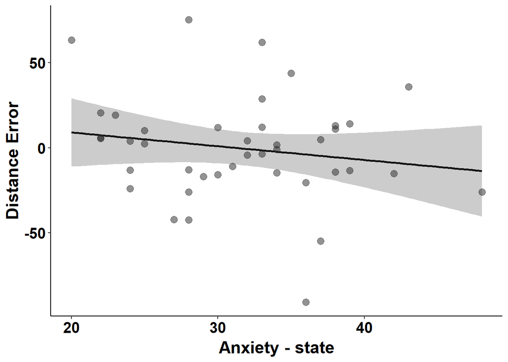

```r
bold.text <- element_text(face = "bold", color = "black")
Fig1 <- ggplot(data = d, aes(x = stai_s, y = distance_error)) + geom_smooth(col = "grey8", method = "lm", level=0.95, alpha = 0.5) +  geom_point(col = "grey 15", alpha = 0.5, size = 3, shape = 19) +   labs(x = "Anxiety - state", y = "Distance Error") + scale_fill_manual() + theme_classic() +  theme(axis.text=element_text(size=15, colour = "black", face="bold"),  axis.title=element_text(size=17), axis.title.y = element_text(margin = margin(t = 0, r = 3, b = 0, l = 0)), axis.title.x =   element_text(margin = margin(t = 5, r = 0, b = 0, l = 0))) + theme(axis.title = bold.text)
Fig1
```

```r
# test correlation: anxiety trait - distance error
cor.test(d$stai_t, d$distance_error, method = "pearson")
```

```
##
##  Pearson's product-moment correlation
##
## data:  d$stai_t and d$distance_error
## t = -2.4307, df = 39, p-value = 0.01977
## alternative hypothesis: true correlation is not equal to 0
## 95 percent confidence interval:
##  -0.6030733 -0.0619872
## sample estimates:
##        cor
## -0.3627204
```

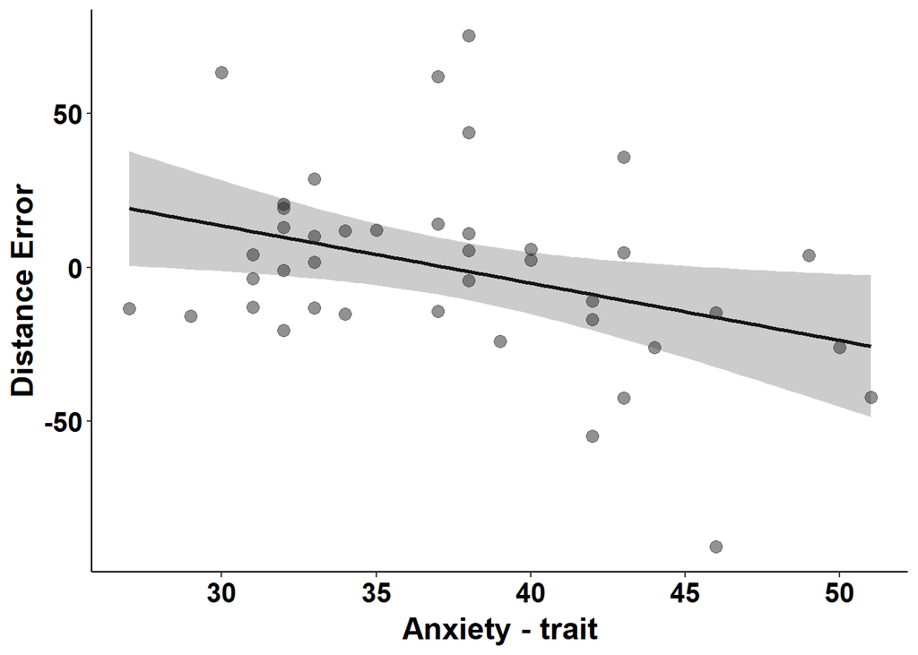

```r
bold.text <- element_text(face = "bold", color = "black")
Fig2 <- ggplot(data = d, aes(x = stai_t, y = distance_error)) + geom_smooth(col = "grey8", method = "lm", level=0.95, alpha = 0.5) +  geom_point(col = "grey 15", alpha = 0.5, size = 3, shape = 19) +   labs(x = "Anxiety - trait", y = "Distance Error") + scale_fill_manual() + theme_classic() +  theme(axis.text=element_text(size=15, colour = "black", face="bold"),  axis.title=element_text(size=17), axis.title.y = element_text(margin = margin(t = 0, r = 3, b = 0, l = 0)), axis.title.x =   element_text(margin = margin(t = 5, r = 0, b = 0, l = 0))) + theme(axis.title = bold.text)
Fig2
```

```r
## check correlations for individual animals
# prepare data
d <- data %>%
  dplyr::group_by(ID, Stimulus) %>%
  dplyr::summarize(distance_error = mean(DistanceError))
```

```
## argument.
```

```r
d <- merge(d, d_qstn, by = "ID")

# loop over animals
for (s in unique(d$Stimulus)) {
ds <- d[d$Stimulus == s,]
print(s)
print(shapiro.test(ds$distance_error))
cor <- cor.test(ds$stai_t, ds$distance_error, method = "spearman", exact = F)
print(cor)
rho <- round(cor$estimate, digits = 3)
p_val <- round(cor$p.value, digits = 3)
scatter.smooth(ds$stai_t, ds$distance_error, main = paste0(s, "\n(rho = ", rho, ", p = ",p_val,")"), pch = 20, cex = 2, col = scales::alpha("gray30",0.5), lwd = 2, xlim = c(25,55), ylim = c(-105,105))}
```

```
## [1] "Crocodile"
##
##  Shapiro-Wilk normality test
##
## data:  ds$distance_error
## W = 0.98104, p-value = 0.715
##
##
##  Spearman's rank correlation rho
##
## data:  ds$stai_t and ds$distance_error
## S = 14621, p-value = 0.08341
## alternative hypothesis: true rho is not equal to 0
## sample estimates:
##        rho
## -0.2736459
```

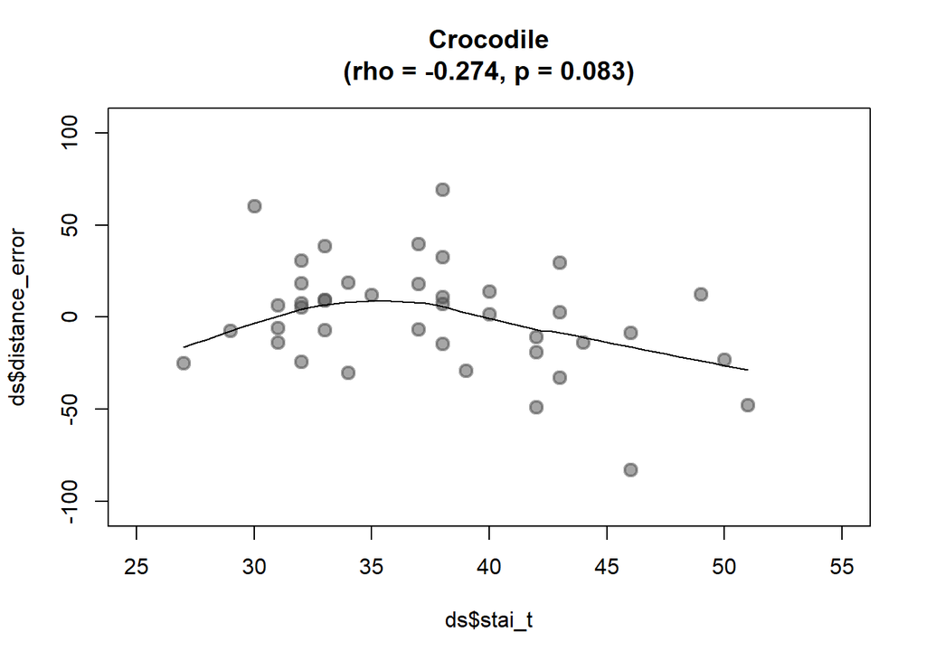

```
## [1] "Deer"
##
##  Shapiro-Wilk normality test
##
## data:  ds$distance_error
## W = 0.91885, p-value = 0.006269
##
##
##  Spearman's rank correlation rho
##
## data:  ds$stai_t and ds$distance_error
## S = 15334, p-value = 0.0319
## alternative hypothesis: true rho is not equal to 0
## sample estimates:
##        rho
## -0.3356793
```

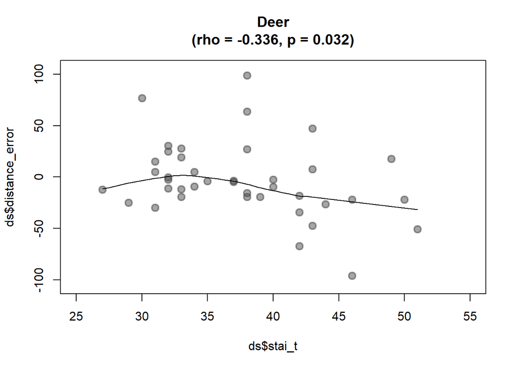

```
## [1] "FinalSnake"
##
##  Shapiro-Wilk normality test
##
## data:  ds$distance_error
## W = 0.97111, p-value = 0.3744
##
##
##  Spearman's rank correlation rho
##
## data:  ds$stai_t and ds$distance_error
## S = 14537, p-value = 0.09237
## alternative hypothesis: true rho is not equal to 0
## sample estimates:
##        rho
## -0.2663067
```

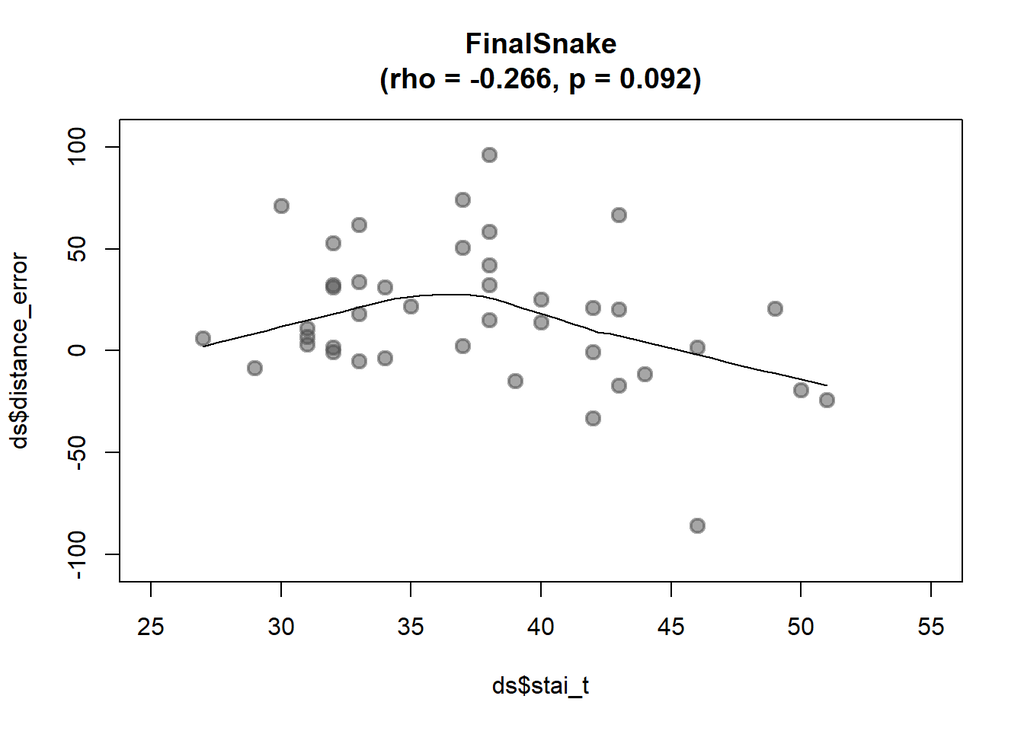

```
## [1] "FinalWolf"
##
##  Shapiro-Wilk normality test
##
## data:  ds$distance_error
## W = 0.92959, p-value = 0.014
##
##
##  Spearman's rank correlation rho
##
## data:  ds$stai_t and ds$distance_error
## S = 14983, p-value = 0.05242
## alternative hypothesis: true rho is not equal to 0
## sample estimates:
##        rho
## -0.3050995
```

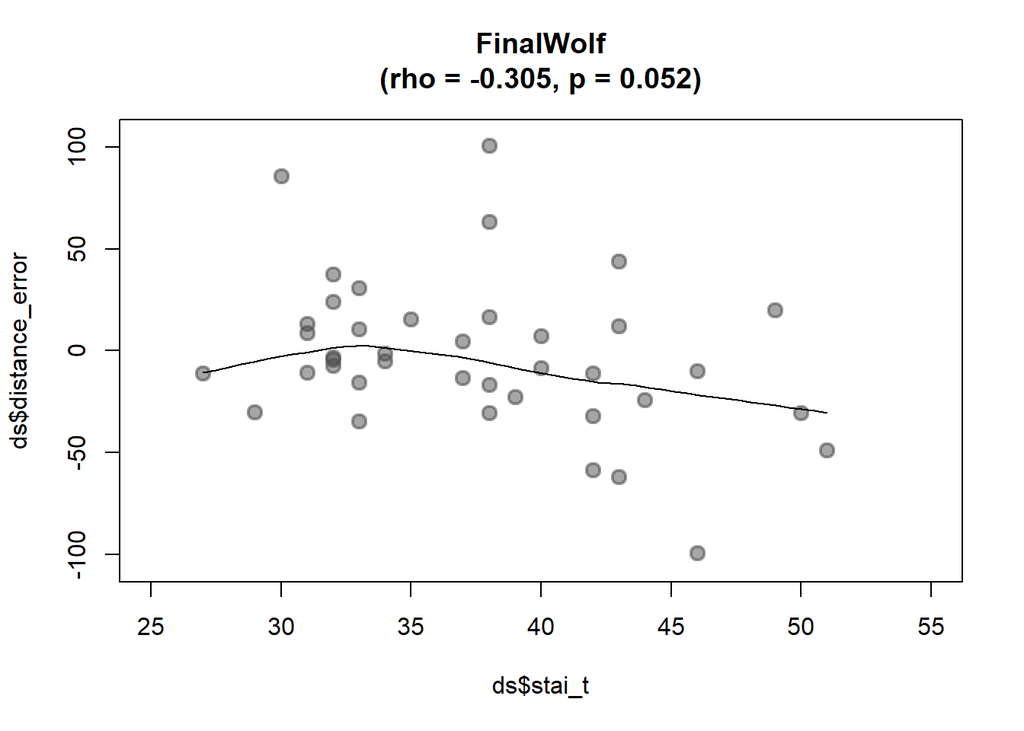

```
## [1] "Pig"
##
##  Shapiro-Wilk normality test
##
## data:  ds$distance_error
## W = 0.97662, p-value = 0.5502
##
##
##  Spearman's rank correlation rho
##
## data:  ds$stai_t and ds$distance_error
## S = 15250, p-value = 0.03604
## alternative hypothesis: true rho is not equal to 0
## sample estimates:
##        rho
## -0.3284275
```

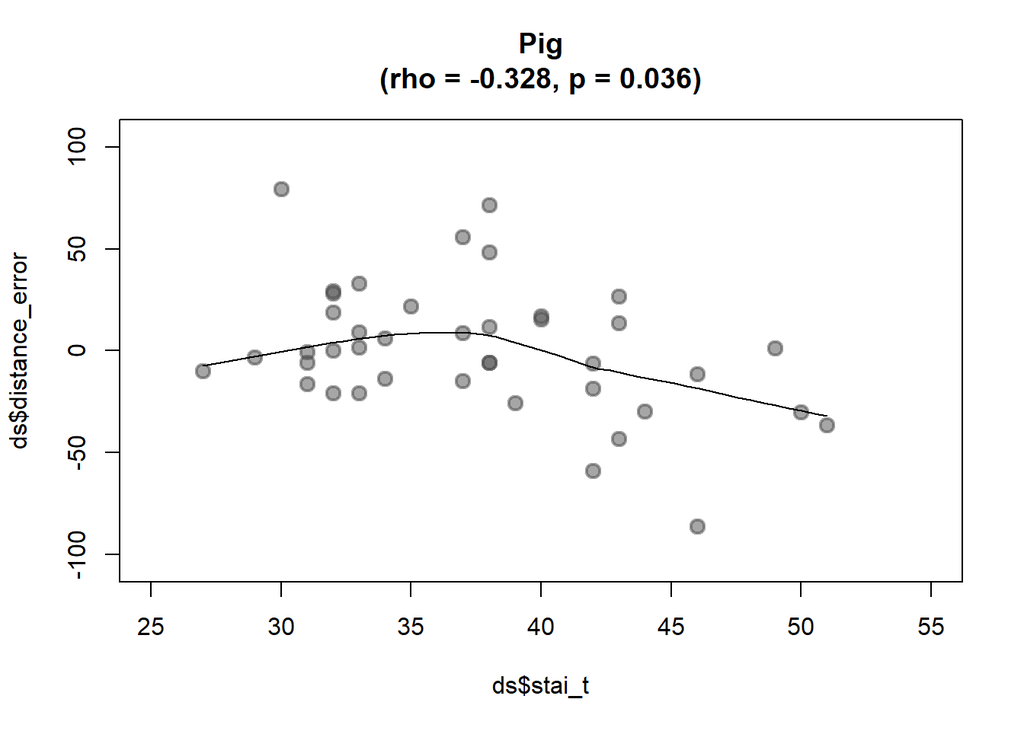

```
## [1] "Rabbit"
##
##  Shapiro-Wilk normality test
##
## data:  ds$distance_error
## W = 0.97404, p-value = 0.4623
##
##
##  Spearman's rank correlation rho
##
## data:  ds$stai_t and ds$distance_error
## S = 15247, p-value = 0.0362
## alternative hypothesis: true rho is not equal to 0
## sample estimates:
##        rho
## -0.3281654
```

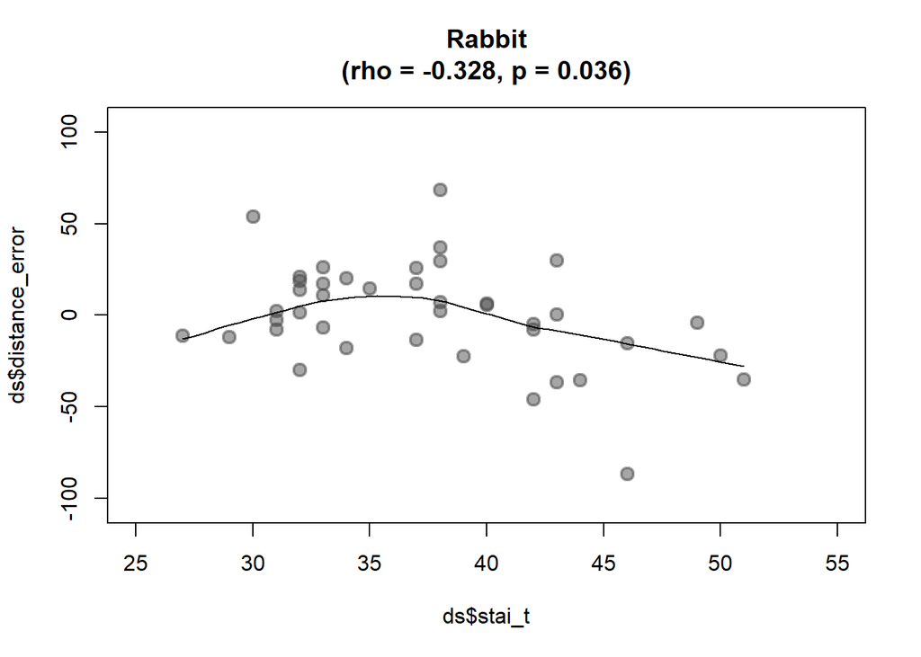

```
## [1] "Scorpio"
##
##  Shapiro-Wilk normality test
##
## data:  ds$distance_error
## W = 0.9713, p-value = 0.3798
##
##
##  Spearman's rank correlation rho
##
## data:  ds$stai_t and ds$distance_error
## S = 15397, p-value = 0.02903
## alternative hypothesis: true rho is not equal to 0
## sample estimates:
##        rho
## -0.3411837
```

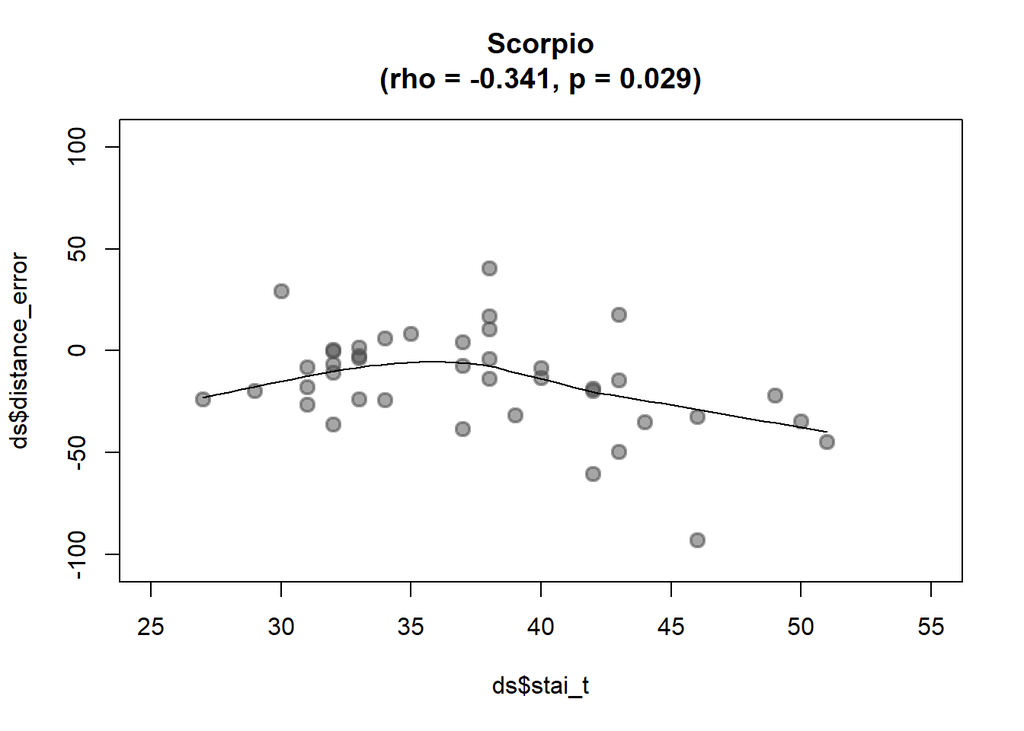

```
## [1] "Turtle"
##
##  Shapiro-Wilk normality test
##
## data:  ds$distance_error
## W = 0.96922, p-value = 0.3251
##
##
##  Spearman's rank correlation rho
##
## data:  ds$stai_t and ds$distance_error
## S = 15375, p-value = 0.03001
## alternative hypothesis: true rho is not equal to 0
## sample estimates:
##        rho
## -0.3392615
```

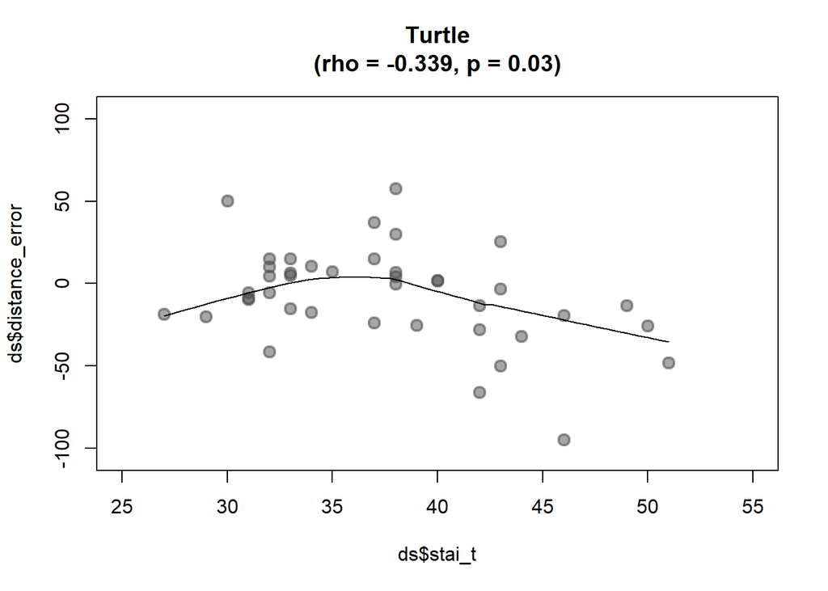

```r
### 6.2. Disgust
dg <- d_sub_start
dg <- dg %>%
  group_by(ID, Stimulus) %>%
  dplyr::summarize(disgust = mean(disgust, na.rm = T))
```

[output not shown]

```r
ds <- data %>%
  dplyr::group_by(ID, Stimulus) %>%
  dplyr::summarize(distance_error = mean(DistanceError))
```

[output not shown]

```r
ds <- merge(ds, dg, by = c("ID","Stimulus"))

# loop over animals
for (s in unique(ds$Stimulus)) {

print(s)
d <- ds[ds$Stimulus == s,]

test <- shapiro.test(d$distance_error)
norm1 <- (test$p.value > 0.05)
test <- shapiro.test(d$disgust)
norm2 <- (test$p.value > 0.05)

ifelse((norm1 == FALSE | norm2 == FALSE), R_method <- "spearman", R_method <- "pearson")

print(s)
cor <- cor.test(d$disgust, d$distance_error, method = R_method)
print(cor)
rho <- round(cor$estimate, digits = 3)
p_val <- round(cor$p.value, digits = 3)

scatter.smooth(d$disgust, d$distance_error, main = paste0(s, " ", R_method, ":", rho, ", p = ",p_val), pch = 20, cex = 2, col = scales::alpha("chocolate4",0.5), lwd = 2, xlim = c(0,7), ylim = c(-105,105))
}
```

```
## [1] "Crocodile"
## [1] "Crocodile"
##
##  Spearman's rank correlation rho
##
## data:  d$disgust and d$distance_error
## S = 12723, p-value = 0.5003
## alternative hypothesis: true rho is not equal to 0
## sample estimates:
##        rho
## -0.1083027
```

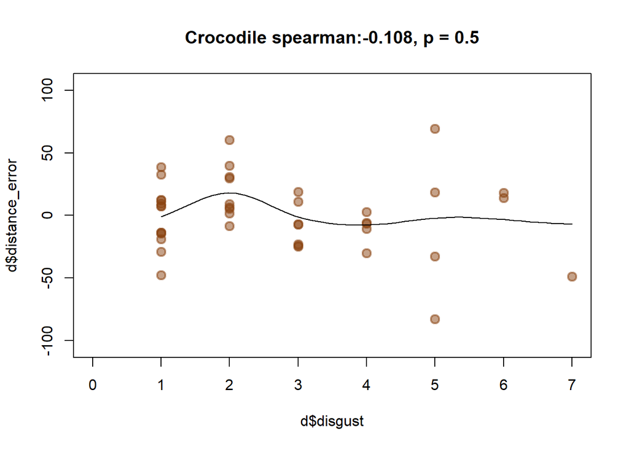

```
## [1] "Deer"
## [1] "Deer"
##
##  Spearman's rank correlation rho
##
## data:  d$disgust and d$distance_error
## S = 10555, p-value = 0.6167
## alternative hypothesis: true rho is not equal to 0
## sample estimates:
##        rho
## 0.08053507
```

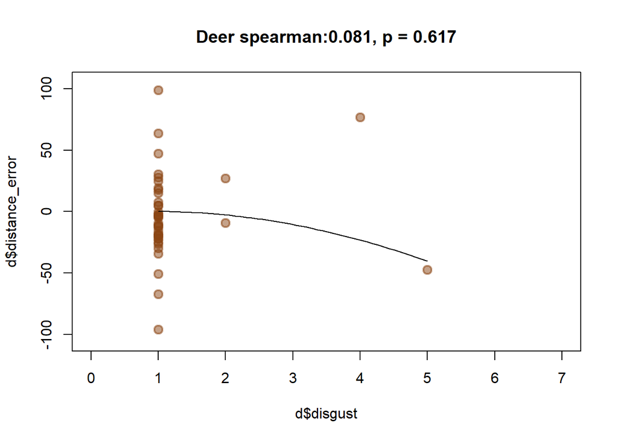

```
## [1] "FinalSnake"
## [1] "FinalSnake"
##
##  Spearman's rank correlation rho
##
## data:  d$disgust and d$distance_error
## S = 13737, p-value = 0.2179
## alternative hypothesis: true rho is not equal to 0
## sample estimates:
##        rho
## -0.1966116
```

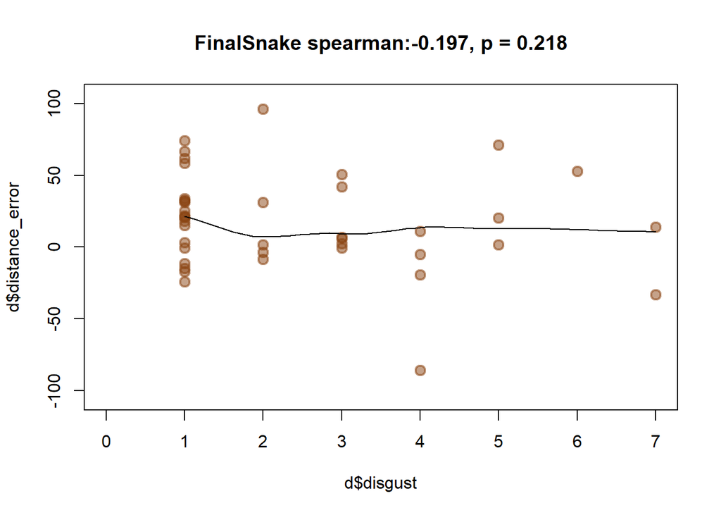

```
## [1] "FinalWolf"
## [1] "FinalWolf"
##
##  Spearman's rank correlation rho
##
## data:  d$disgust and d$distance_error
## S = 11922, p-value = 0.811
## alternative hypothesis: true rho is not equal to 0
## sample estimates:
##         rho
## -0.03853447
```

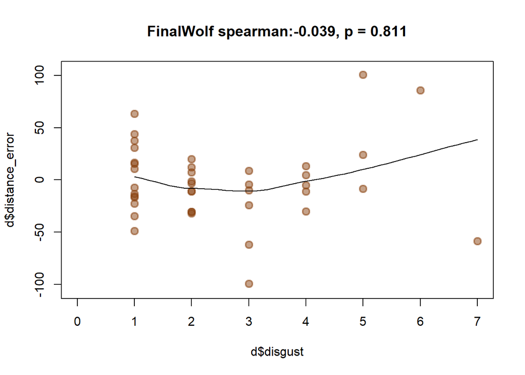

```
## [1] "Pig"
## [1] "Pig"
##
##  Spearman's rank correlation rho
##
## data:  d$disgust and d$distance_error
## S = 14816, p-value = 0.06531
## alternative hypothesis: true rho is not equal to 0
## sample estimates:
##        rho
## -0.2905894
```

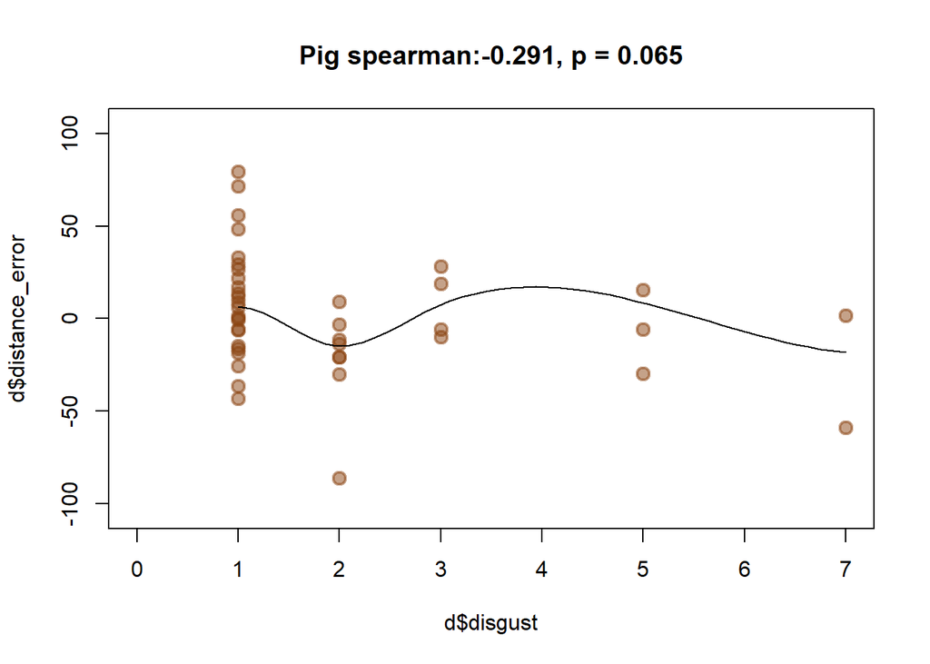

```
## [1] "Rabbit"
## [1] "Rabbit"
##
##  Spearman's rank correlation rho
##
## data:  d$disgust and d$distance_error
## S = 11044, p-value = 0.8135
## alternative hypothesis: true rho is not equal to 0
## sample estimates:
##        rho
## 0.03800908
```

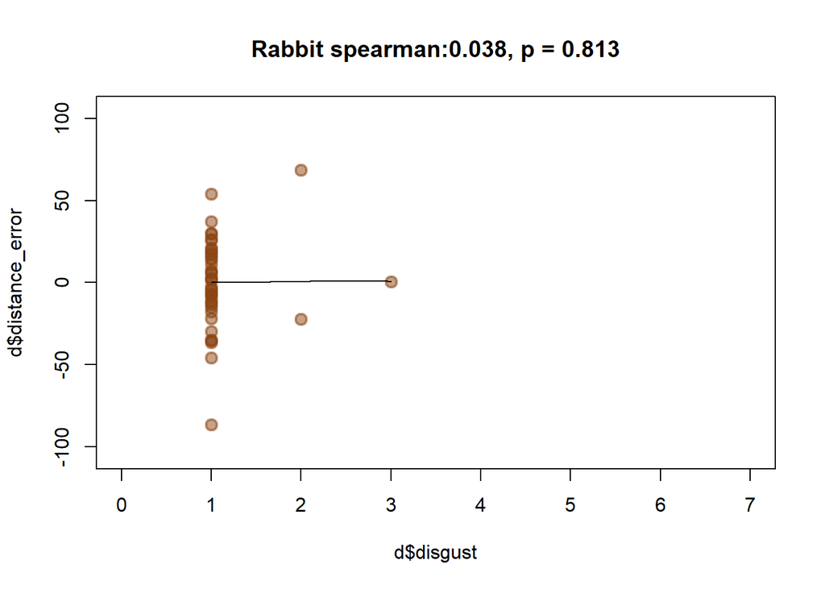

```
## [1] "Scorpio"
## [1] "Scorpio"
##
##  Spearman's rank correlation rho
##
## data:  d$disgust and d$distance_error
## S = 12949, p-value = 0.4252
## alternative hypothesis: true rho is not equal to 0
## sample estimates:
##        rho
## -0.1279716
```

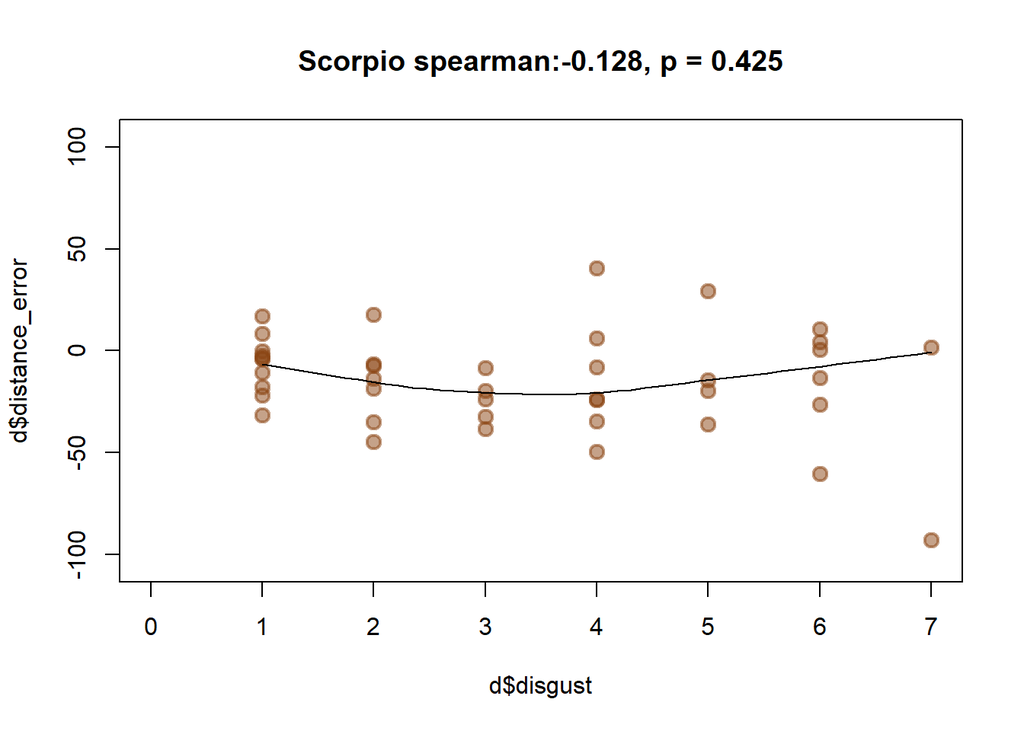

```
## [1] "Turtle"
## [1] "Turtle"
##
##  Spearman's rank correlation rho
##
## data:  d$disgust and d$distance_error
## S = 15115, p-value = 0.04371
## alternative hypothesis: true rho is not equal to 0
## sample estimates:
##        rho
## -0.3166238
```

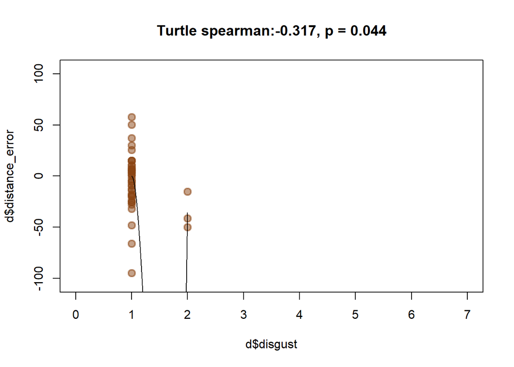